# Jupyter学习-机器学习演示

### 第一步：导入数据分析库pandas，数据可视化库matplotlib

```python
import pandas as pd
import matplotlib.pyplot as plt
%matplotlib inline
```

```python
dataset = pd.read_csv('./studentscores.csv')
dataset.head()
```

|  | Hours | Scores |
| --- | --- | --- |
| 0 | 2.5 | 21 |
| 1 | 5.1 | 47 |
| 2 | 3.2 | 27 |
| 3 | 8.5 | 75 |
| 4 | 3.5 | 30 |

```python
dataset.shape
```

```
(25, 2)
```

```python
dataset.columns
```

```
Index(['Hours', 'Scores'], dtype='object')
```

```python
dataset.info()
```

```
<class 'pandas.core.frame.DataFrame'>
RangeIndex: 25 entries, 0 to 24
Data columns (total 2 columns):
 #   Column  Non-Null Count  Dtype
---  ------  --------------  -----
 0   Hours   25 non-null     float64
 1   Scores  25 non-null     int64
dtypes: float64(1), int64(1)
memory usage: 464.0 bytes
```

#### 常用的描述统计学特征的函数

```python
dataset.describe()
```

|  | Hours | Scores |
| --- | --- | --- |
| count | 25.000000 | 25.000000 |
| mean | 5.012000 | 51.480000 |
| std | 2.525094 | 25.286887 |
| min | 1.100000 | 17.000000 |
| 25% | 2.700000 | 30.000000 |
| 50% | 4.800000 | 47.000000 |
| 75% | 7.400000 | 75.000000 |
| max | 9.200000 | 95.000000 |

### 第三步：特征提取

```python
feature_columns = ['Hours']
lable_column = ['Scores']
```

```python
features = dataset[feature_columns]
lable = dataset[lable_column]
```

```python
features.head()
```

|  | Hours |
| --- | --- |
| 0 | 2.5 |
| 1 | 5.1 |
| 2 | 3.2 |
| 3 | 8.5 |
| 4 | 3.5 |

```python
type(features)
```

```
pandas.core.frame.DataFrame
```

```python
lable.head()
```

|  | Scores |
| --- | --- |
| 0 | 21 |
| 1 | 47 |
| 2 | 27 |
| 3 | 75 |
| 4 | 30 |

```python
type(lable)
```

```
pandas.core.frame.DataFrame
```

```python
X = features.values
```

```python
Y = lable.values
```

X就变成了numpy的array数组类型

```python
X
```

```
array([[2.5],
       [5.1],
       [3.2],
       [8.5],
       [3.5],
       [1.5],
       [9.2],
       [5.5],
       [8.3],
       [2.7],
       [7.7],
       [5.9],
       [4.5],
       [3.3],
       [1.1],
       [8.9],
       [2.5],
       [1.9],
       [6.1],
       [7.4],
       [2.7],
       [4.8],
       [3.8],
       [6.9],
       [7.8]])
```

```python
type(X)
```

```
numpy.ndarray
```

### 第四步：建立模型

#### 拆分数据，四分之三的数据作为训练集，四分之一的数据作为测试集

```python
from sklearn.model_selection import train_test_split
X_train,X_test,Y_train,Y_test = train_test_split(X,Y,test_size = 1/4,random_state = 0)
```

##### sklearn.model_selection.train_test_split随机划分训练集和测试集

[train_test_split()函数](https://blog.csdn.net/qq_39355550/article/details/82688014)

#### 一般形式

train_test_split是交叉验证中常用的函数，功能是从样本中随机的按比例选取train data和testdata，形式为：  
X_train,X_test,y_train,y_test=cross_validation.train_test_split(train_data,train_target,test_size=0.4, random_state=0)

#### 参数解释

train_data：所要划分的样本特征集

train_target：所要划分的样本结果

test_size：样本占比，如果是整数的话就是样本的数量

random_state：是随机数的种子

随机数种子：其实就是该组随机数的编号，在需要重复试验的时候，保证得到一组一样的随机数。比如你每次都填1，其他参数一样的情况下你得到的随机数组是一样的。不填的话默认值为False，即每次切分的比例虽然相同，但是切分的结果不同。

随机数的产生取决于种子，随机数和种子之间的关系遵从以下两个规则：

种子不同，产生不同的随机数；种子相同，即使实例不同也产生相同的随机数。

#### 用训练的数据集进行训练

```python
from sklearn.linear_model import LinearRegression
regressor = LinearRegression()
regressor = regressor.fit(X_train,Y_train)
```

#### 对测试集进行预测

```python
Y_pred = regressor.predict(X_test)
```

### 可视化

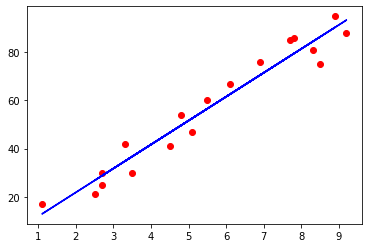

```python
#散点图：红色点表示训练集的点
plt.scatter(X_train,Y_train,color = 'red')
#线图：蓝色线表示由训练集训练出的线性回归模型
plt.plot(X_train,regressor.predict(X_train),color = 'blue')
plt.show()
```

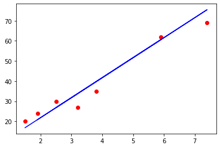

```python
#散点图：红色点表示测试集的点
plt.scatter(X_test,Y_test,color = 'red')
#线图：蓝色线表示由训练集训练出的线性回归模型
plt.plot(X_test,regressor.predict(X_test),color = 'blue')
plt.show()
```

#### 训练集就是平时的课后习题

#### 测试集就是高考考试

#### 真实情况是，含有三个集

```
1.训练集
2.验证集
3.测试集
```

平时成绩好，一到高考就蔫了，在数据中称为，过拟合

传统的机器学习里，常用的训练集和测试集的比例为四比一  
训练集：测试集 = 4:1

目前因其数据量庞大，故而训练集占主要部分，而测试集只需要极少一部分作为验证

# Markdown学习

1.六级标题，用#号表示，1个#号代表一标题，6个代表六级标题

# 标题1

## 标题2

### 标题3

#### 标题4

##### 标题5

###### 标题6

2.应用的话用>表示

> 这是一段引用

## 二、字体

**加粗**

要加粗的文字**左右**用两个*号包起来

*斜体*

要斜体的文字左右分别用一个*号包起来

*斜体加粗*

要斜体和加粗的文字左右分别分别用三个*号包起来

删除线

要加删除的文字左右分别用两个~号包起来

## 二、引用

在引用的文字前加>即可。引用也可以嵌套，如加两个>>三个>>> n个... 貌似可以一直加下去，但没神马卵用

> 这是引用的内容

> > 这是引用的内容

## 四、分割线

三个或者三个以上的 - 或者 * 都可以。

## 五、图片

[figure not shown]

图片alt就是显示在图片下面的文字，相当于对图片内容的解释。 图片title是图片的标题，当鼠标移到图片上时显示的内容。title可加可不加

示例

[figure not shown]

##### 上传本地图片直接点击导航栏的图片标志，选择图片即可

[markdown图床](https://www.jianshu.com/p/ea1eb11db63f)

## 六、超链接

语法

超链接名 title可加可不加

[简书](http://jianshu.com) [百度](http://baidu.com)

> 注：Markdown本身语法不支持链接在新页面中打开，貌似简书做了处理，是可以的。别的平台可能就不行了，如果想要在新页面中打开的话可以用html语言的a标签代替。

超链接名

示例 [简书](https://www.jianshu.com/u/1f5ac0cf6a8b)

## 七、列表

### 无序列表

语法： 无序列表用 - + * 任何一种都可以

- 列表内容
- 列表内容
- 列表内容

注意：- + * 跟内容之间都要有一个空格

### 有序列表

语法： 数字加点

1. 列表内容
2. 列表内容
3. 列表内容

注意：序号跟内容之间要有空格

### 列表嵌套

#### 上一级和下一级之间敲三个空格即可

- 一级无序列表内容
  - 二级无序列表内容
  - 二级无序列表内容
  - 二级无序列表内容
- 一级无序列表内容
  1. 二级有序列表内容
  2. 二级有序列表内容
  3. 二级有序列表内容
1. 一级有序列表内容
   - 二级无序列表内容
   - 二级无序列表内容
   - 二级无序列表内容
1. 一级有序列表内容
   1. 二级无序列表内容
   2. 二级无序列表内容
   3. 二级无序列表内容

## 八、表格

语法：

| 表头 | 表头 | 表头 |
| --- | --- | --- |
| 内容 | 内容 | 内容 |
| 内容 | 内容 | 内容 |

第二行分割表头和内容。

- 有一个就行，为了对齐，多加了几个 文字默认居左 -两边加：表示文字居中 -右边加：表示文字居右 注：原生的语法两边都要用 | 包起来。此处省略

| 姓名 | 技能 | 排行 |
| --- | --- | --- |
| 刘备 | 哭 | 大哥 |
| 关羽 | 打 | 二哥 |
| 张飞 | 骂 | 三弟 |

## 九、代码

语法：  
单行代码：代码之间分别用一个反引号包起来

```
`代码内容`
```

代码块：代码之间分别用三个反引号包起来，且两边的反引号单独占一行

(

```
)
  代码...
  代码...
  代码...
(
```

)

> 注：为了防止转译，前后三个反引号处加了小括号，实际是没有的。这里只是用来演示，实际中去掉两边小括号即可。

`create database hero;`

(

```
)
    function fun(){
         echo "这是一句非常牛逼的代码";
    }
    fun();
(
```

)

效果如下：  
单行代码

```
function fun(){
  echo "这是一句非常牛逼的代码";
}
fun();
```

## 十、流程图

```
flow
st=>start: 开始
op=>operation: My Operation
cond=>condition: Yes or No?
e=>end
st->op->cond
cond(yes)->e
cond(no)->op
&
```

[figure not shown]